# Simulation experiment (4)

## Design of the experiment

Same as in experiment 1. In this experiment we focus on differences in the SD of the measurement error between the training and validation datasets. If the validation data has larger (or smaller) measurement error than the training dataset, and we know this, can the EIV model with known measurement error then account for this in the predictions? The linear regression model and the second EIV model are unaltered. Other parameter values are kept fixed:

Table: Parameter values for the scenario’s of experiment 4.

| Parameter | Values |
| --- | --- |
| $N$ | 200 |
| $\mu_x$ | 0 |
| $\sigma_x$ | 1 |
| $\alpha$ | 0 |
| $\beta$ | 1 |
| $\sigma_y$ | 0.1 |
| Tails measurement error | Normal distribution |
| $\tau_x$ | 0.01, 0.1, 0.2 |
| $\tau_{xy}$ | 1 |
| $\rho$ | 0 |
| $\sigma_u(\text{validation}) / \sigma_u(\text{training})$ | 0.8, 1, 1.2, 1.5 |

## Description of the models

- linear regression
- EIV-regression with known SD of measurement error in the training data only. We assume that the validation data has the same measurement error as the training data.
- EIV-regression with known SD of measurement error: the model fitting is the same as before, but in the prediction part, we allow the user to give a new value for the SD of the measurement error in the validation dataset (which we assume is known too).
- EIV-regression with prior on SD of measurement error

## Results

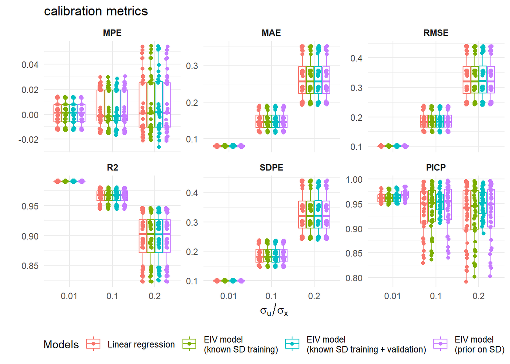

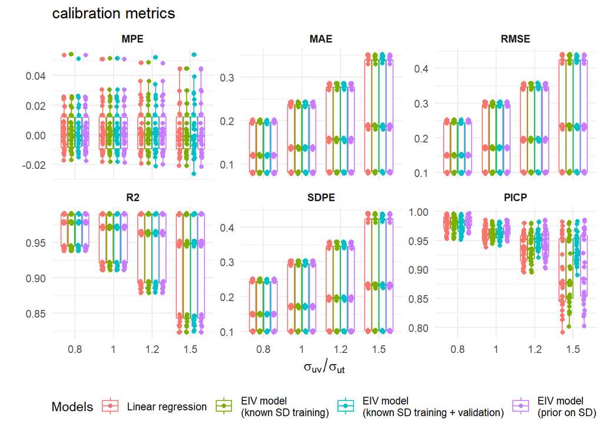

The following figure display the $\hat{R}$ statistic of the MCMC for each of the model parameters. The red dashed lines are at 1.00 and 1.01. The boxplots are aggregated across scenario’s because the values were similar in each of them and all well below 1.01.

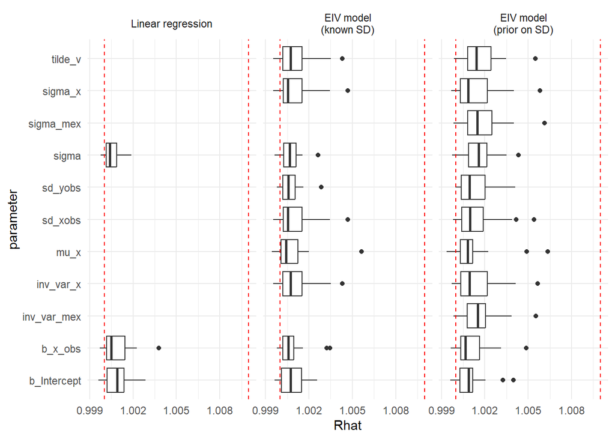